# AMPHIBIAN Working Group 2014-2015

# Download the SPSS data file

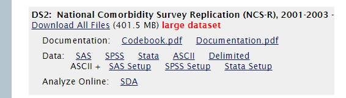

# Let’s get set

```r
work <- "c:/work/shows/switch2r" # my working folder you edit here
setwd(work) # change to it
getwd() # check it
```

```
## [1] "c:/work/shows/switch2r"
```

# I’ve downloaded the SPSS file to a subfolder here (NCSR)

```r
dir("./NCSR")
```

```
## [1] "20240-0002-Codebook.pdf"      "20240-0002-Data.sav"
## [3] "20240-0002-Data.txt"          "20240-0002-Documentation.pdf"
## [5] "20240-0002-Setup.sas"
```

# We’ll use the sjPlot package to read in the SPSS data

and generate a nice data dictionary

```r
spssdata <- sji.SPSS("./NCSR/20240-0002-Data.sav")
# sji.viewSPSS(spssdata) # opens in the Rstudio Viewer Panel
# Or in a browser window if you're running the R Console
```

# Let’s save that codebook

```r
#sji.viewSPSS(spssdata, file="codebook.html", showFreq = TRUE, useViewer = FALSE)
codebookpath <- file.path(work,"codebook.html")
```

The codebook

But that link only works on your (i.e., my) local computer

Viewers of this presentation can see the codebook I generated [on my dropbox](https://dl.dropboxusercontent.com/u/458793/Switch2R/codebook.html)

# Let’s make a summated rating scale score

Psychotic experiences

- PS1A Ever see vision that others couldn’t see
- PS1B Ever hear voices others couldn’t hear
- PS1C Ever have mind control experience
- PS1D Ever feel mind taken over by strange forces
- PS1E Ever exp communication attempts from strange forces
- PS1F Unjust plot to harm you/have people follow-nobody believe

Each coded 1=Yes, 5=No

# Look at the data

```r
PSitems <- c("PS1A", "PS1B", "PS1C", "PS1D", "PS1E", "PS1F")
describe(spssdata[PSitems])
```

```
## spssdata[PSitems]
##
##  6  Variables      9282  Observations
## ---------------------------------------------------------------------------
## PS1A
##       n missing  unique    Info    Mean
##    2349    6933       2    0.25    4.63
##
## 1 (217, 9%), 5 (2132, 91%)
## ---------------------------------------------------------------------------
## PS1B
##       n missing  unique    Info    Mean
##    2349    6933       2    0.17   4.753
##
## 1 (145, 6%), 5 (2204, 94%)
## ---------------------------------------------------------------------------
## PS1C
##       n missing  unique    Info    Mean
##    2352    6930       2    0.02   4.968
##
## 1 (19, 1%), 5 (2333, 99%)
## ---------------------------------------------------------------------------
## PS1D
##       n missing  unique    Info    Mean
##    2353    6929       2    0.01   4.981
##
## 1 (11, 0%), 5 (2342, 100%)
## ---------------------------------------------------------------------------
## PS1E
##       n missing  unique    Info    Mean
##    2352    6930       2    0.04   4.951
##
## 1 (29, 1%), 5 (2323, 99%)
## ---------------------------------------------------------------------------
## PS1F
##       n missing  unique    Info    Mean
##    2352    6930       2    0.05   4.937
##
## 1 (37, 2%), 5 (2315, 98%)
## ---------------------------------------------------------------------------
```

Looks like a skip pattern

# Kessler says…

- A total of 9282 respondents participated (2001-2003)
- All respondents completed a Part I diagnostic interview (WHO-CIDI)
- A probability sample of 5692 also received Part II (additional disorders)
- A random sub-sample of Part II respondents (n = 2322) was administered the NAP screen
- NAP (Non-affective psychosis)
- Our N=2349-2353 is pretty close to that

Kessler RC, Birnbaum H, Demler O, Falloon IR, Gagnon E, Guyer M, Howes MJ, Kendler KS, Shi L, Walters E. The prevalence and correlates of nonaffective psychosis in the National Comorbidity Survey Replication (NCS-R). [Biol Psychiatry. 2005;58(8):668-76.](http://www.ncbi.nlm.nih.gov/pmc/articles/PMC2847859/)

# Right ways and wrong ways to make a sum score

Remember

```r
table(spssdata$PS1A)
```

```
##
##    1    5
##  217 2132
```

# Right ways and wrong ways to make a sum score

This works

```
spssdata$count.ok <- (spssdata$PS1A==1)+
  (spssdata$PS1B==1)+(spssdata$PS1C==1)+
  (spssdata$PS1D==1)+(spssdata$PS1E==1)+
  (spssdata$PS1F==1)
```

# Right ways and wrong ways to make a sum score

This does not

```
spssdata$count.notok <- (spssdata$PS1A==1)
  +(spssdata$PS1B==1)
  +(spssdata$PS1C==1)
  +(spssdata$PS1D==1)
  +(spssdata$PS1E==1)
  +(spssdata$PS1F==1)
```

# Right ways and wrong ways to make a sum score

See

```r
spssdata$count.ok <- (spssdata$PS1A==1)+
  (spssdata$PS1B==1)+(spssdata$PS1C==1)+
  (spssdata$PS1D==1)+(spssdata$PS1E==1)+
  (spssdata$PS1F==1)
summary(spssdata$count.ok)
```

```
##    Min. 1st Qu.  Median    Mean 3rd Qu.    Max.    NA's
##   0.000   0.000   0.000   0.194   0.000   6.000    6938
```

# Right ways and wrong ways to make a sum score

Let’s check

```r
spssdata$check <- paste0(as.character(spssdata$PS1A),
  as.character(spssdata$PS1B),as.character(spssdata$PS1C),
  as.character(spssdata$PS1D),as.character(spssdata$PS1E),
  as.character(spssdata$PS1F))
```

# Right ways and wrong ways to make a sum score

Let’s check

```r
head(spssdata[which(spssdata$count==0),c("check","count.ok")])
```

```
##     check count.ok
## 8  555555        0
## 12 555555        0
## 18 555555        0
## 24 555555        0
## 25 555555        0
## 26 555555        0
```

# Right ways and wrong ways to make a sum score

Let’s check

```r
head(spssdata[which(spssdata$count==1),c("check","count.ok")])
```

```
##      check count.ok
## 17  155555        1
## 19  155555        1
## 212 155555        1
## 321 515555        1
## 378 155555        1
## 381 555551        1
```

# Right ways and wrong ways to make a sum score

Let’s check

```r
head(spssdata[which(spssdata$count==2),c("check","count.ok")])
```

```
##      check count.ok
## 313 115555        2
## 367 515551        2
## 453 115555        2
## 501 155551        2
## 660 115555        2
## 721 155515        2
```

# Right ways and wrong ways to make a sum score

Let’s check

```r
head(spssdata[which(spssdata$count==3),c("check","count.ok")])
```

```
##       check count.ok
## 1176 115155        3
## 2254 115551        3
## 3084 115155        3
## 3620 111555        3
## 3658 115551        3
## 4115 111555        3
```

# Right ways and wrong ways to make a sum score

Let’s check

```r
head(spssdata[which(spssdata$count==4),c("check","count.ok")])
```

```
##       check count.ok
## 38   151115        4
## 3793 111551        4
## 4426 115115        4
## 6260 115511        4
## 6299 115511        4
## 7040 111515        4
```

# Right ways and wrong ways to make a sum score

Let’s check

```r
head(spssdata[which(spssdata$count==5),c("check","count.ok")])
```

```
##       check count.ok
## 6721 111511        5
```

# Right ways and wrong ways to make a sum score

Let’s check

```r
head(spssdata[which(spssdata$count==6),c("check","count.ok")])
```

```
##       check count.ok
## 1453 111111        6
## 4460 111111        6
```

# Using *scoreItems* from package *psych*

```r
psitems <- c("ps1a.i", "ps1b.i", "ps1c.i", "ps1d.i", "ps1e.i", "ps1f.i")
# Make indicator versions of response items
spssdata$ps1a.i <- as.numeric(spssdata$PS1A==1)
spssdata$ps1b.i <- as.numeric(spssdata$PS1B==1)
spssdata$ps1c.i <- as.numeric(spssdata$PS1C==1)
spssdata$ps1d.i <- as.numeric(spssdata$PS1D==1)
spssdata$ps1e.i <- as.numeric(spssdata$PS1E==1)
spssdata$ps1f.i <- as.numeric(spssdata$PS1F==1)
```

# Using *scoreItems* from package *psych*

```r
key <- c(1,1,1,1,1,1) # the "right" answers
results <- scoreItems(
  items = spssdata[psitems],
  keys = key,
  missing = TRUE , impute = "none"  # person's non-missing mean
  #                                   response used for missing
  )
```

# Display scoreItem results

```r
results
```

```
## Call: scoreItems(keys = key, items = spssdata[psitems], missing = TRUE,
##     impute = "none")
##
## (Standardized) Alpha:
##         A1
## alpha 0.53
##
## Standard errors of unstandardized Alpha:
##         [,1]
## ASE   0.0094
##
## Standardized Alpha of observed scales:
##                [,1]
## alpha.observed 0.53
##
## Average item correlation:
##           [,1]
## average.r 0.16
##
##  Guttman 6* reliability:
##          [,1]
## Lambda.6 0.52
##
## Signal/Noise based upon av.r :
##              [,1]
## Signal/Noise  1.1
##
## Scale intercorrelations corrected for attenuation
##  raw correlations below the diagonal, alpha on the diagonal
##  corrected correlations above the diagonal:
##
## Note that these are the correlations of the complete scales based on the correlation matrix,
##  not the observed scales based on the raw items.
##      [,1]
## [1,] 0.53
##
##  In order to see the item by scale loadings and frequency counts of the data
##  print with the short option = FALSE
```

# Display the **str**ucture of the *results*

```r
str(results)
```

```
## List of 17
##  $ scores        : num [1:9282, 1] NaN NaN NaN NaN NaN NaN NaN 0 NaN NaN ...
##   ..- attr(*, "dimnames")=List of 2
##   .. ..$ : NULL
##   .. ..$ : chr "A1"
##  $ missing       : num [1:9282, 1] 6 6 6 6 6 6 6 0 6 6 ...
##  $ alpha         : num [1, 1] 0.527
##   ..- attr(*, "dimnames")=List of 2
##   .. ..$ : chr "alpha"
##   .. ..$ : chr "A1"
##  $ av.r          : num [1, 1] 0.157
##   ..- attr(*, "dimnames")=List of 2
##   .. ..$ : chr "average.r"
##   .. ..$ : NULL
##  $ sn            : num [1, 1] 1.11
##   ..- attr(*, "dimnames")=List of 2
##   .. ..$ : chr "Signal/Noise"
##   .. ..$ : NULL
##  $ n.items       : num 6
##  $ item.cor      : num [1:6, 1] 0.755 0.726 0.445 0.359 0.517 ...
##   ..- attr(*, "dimnames")=List of 2
##   .. ..$ : chr [1:6] "ps1a.i" "ps1b.i" "ps1c.i" "ps1d.i" ...
##   .. ..$ : chr "A1"
##  $ cor           : num [1, 1] 1
##  $ corrected     : num [1, 1] 0.527
##  $ G6            : num [1, 1] 0.523
##   ..- attr(*, "dimnames")=List of 2
##   .. ..$ : chr "Lambda.6"
##   .. ..$ : NULL
##  $ item.corrected: num [1:6, 1] 0.44 0.521 0.427 0.353 0.498 ...
##   ..- attr(*, "dimnames")=List of 2
##   .. ..$ : chr [1:6] "ps1a.i" "ps1b.i" "ps1c.i" "ps1d.i" ...
##   .. ..$ : chr "A1"
##  $ response.freq : num [1:6, 1:3] 0.908 0.938 0.992 0.995 0.988 ...
##   ..- attr(*, "dimnames")=List of 2
##   .. ..$ : chr [1:6] "ps1a.i" "ps1b.i" "ps1c.i" "ps1d.i" ...
##   .. ..$ : chr [1:3] "0" "1" "miss"
##  $ raw           : logi FALSE
##  $ alpha.ob      : num [1, 1] 0.527
##   ..- attr(*, "dimnames")=List of 2
##   .. ..$ : chr "alpha.observed"
##   .. ..$ : NULL
##  $ num.ob.item   : num 6
##  $ ase           : num [1, 1] 0.00941
##  $ Call          : language scoreItems(keys = key, items = spssdata[psitems], missing = TRUE,      impute = "none")
##  - attr(*, "class")= chr [1:2] "psych" "score.items"
```

# Using *scoreItems* from package *psych*

```r
summary(results$score)
```

```
##        A1
##  Min.   :0.000
##  1st Qu.:0.000
##  Median :0.000
##  Mean   :0.032
##  3rd Qu.:0.000
##  Max.   :1.000
##  NA's   :6929
```

# Using *scoreItems* from package *psych*

```r
results$pscount <- 6*results$score
summary(results$pscount)
```

```
##        A1
##  Min.   :0.000
##  1st Qu.:0.000
##  Median :0.000
##  Mean   :0.195
##  3rd Qu.:0.000
##  Max.   :6.000
##  NA's   :6929
```

# But

How do we get *results$pscount* back into the working data set?

```r
spssdata$pscount.master <- scoreItems(items = spssdata[psitems],
  keys = key, missing = TRUE , impute = "none")[[1]]*6
summary(spssdata$pscount.master)
```

```
##        A1
##  Min.   :0.000
##  1st Qu.:0.000
##  Median :0.000
##  Mean   :0.195
##  3rd Qu.:0.000
##  Max.   :6.000
##  NA's   :6929
```

# Display the internal consistency reliability coefficient

```r
results$alpha
```

```
##              A1
## alpha 0.5271367
```

# Save alpha to two decimal places

```r
alpha <- round(results$alpha,2)
```

My markdown code

```
The internal consistency reliability coefficient for the sum of the
psychotic experiences scale is 'r alpha'.
```

The internal consistency reliability coefficient for the sum of the psychotic experiences scale is 0.53.

# Display the structure and report the item response frequencies

```r
str(results$response.freq)
```

```
##  num [1:6, 1:3] 0.908 0.938 0.992 0.995 0.988 ...
##  - attr(*, "dimnames")=List of 2
##   ..$ : chr [1:6] "ps1a.i" "ps1b.i" "ps1c.i" "ps1d.i" ...
##   ..$ : chr [1:3] "0" "1" "miss"
```

```r
results$response.freq
```

```
##                0           1      miss
## ps1a.i 0.9076203 0.092379736 0.7469295
## ps1b.i 0.9382716 0.061728395 0.7469295
## ps1c.i 0.9919218 0.008078231 0.7466063
## ps1d.i 0.9953251 0.004674883 0.7464986
## ps1e.i 0.9876701 0.012329932 0.7466063
## ps1f.i 0.9842687 0.015731293 0.7466063
```

# Review of things we accomplished today

- Big ideas
- Packages
- Commands and functions
- Skills and tasks

# Big ideas

- using public data
- tidy data
- documentation
- seeds

# Packages

- lubridate
- gmodels (CrossTab)
- sjPlot (sji.SPSS and others)
- psych

# Commands and functions

- setwd, getwd
- CrossTable (gModels)
- sample
- runif
- names
- tolower
- as.numeric, as.character
- head
- str
- file.path
- paste0
- scoreItems (psych)

# Skills and tasks

- install packages
- load packages
- set the working directory
- relative paths
- read data from the internet
- read data from SPSS/SAV file
- refer to specific variables
- refer to specific observations
- made a cross tab
- made new variables
- generate random data
- define a new function
- working with dates

# Next meeting

Analysis with R

Use R to do multivariable analysis

- Linear regression
- Logistic regression
- Survival analysis
- Repeated measures mixed models

Monday, December 8, 2014, 2-3pm.